# MachineLearningProject

Michael Green

June 14, 2016

## Overview

This analysis creates a prediction model for the Human Activity Recognition(HAR) study on weightlifting. The study description is at http://groupware.les.inf.puc-rio.br/har. The goal of the study was to record data that could be used to determine the quality of an exercise movement. The study used sensors to record data when subjects performed a specified weightlifting exercise in different ways. The different movements used to execute the exercise were graded as A,B,C,D,E. The provided training dataset includes the grade and sensor readings for each movement execution. From this data we want to create a prediction model which can correctly predit grades for movements. The accuracy of the prediction models are determined by testing against a dataset partitioned from the training dataset.

## Data Processing

#### Loading the Data

The data is provided by the HAR and we are directly able to load it from the specified url’s. The training data includes the grade for each movement in the classe column. The test data does not include the classe column.

```r
testing <- read.csv("https://d396qusza40orc.cloudfront.net/predmachlearn/pml-testing.csv")
training <- read.csv("https://d396qusza40orc.cloudfront.net/predmachlearn/pml-training.csv")

dim(training)
```

```
## [1] 19622   160
```

```r
dim(testing)
```

```
## [1]  20 160
```

### Cleaning the Data

We want to eliminate unnecessary columns, columns which are overwhelmingly NA or empty, highly correlated columns

‘X’, ‘user_name’, ‘raw_timestamp_part_1’, ‘raw_timestamp_part_2’, ‘cvtd_timestamp’, ‘new_window’

```r
testing <- subset(testing, select=-c(1:7))
training <- subset(training, select=-c(1:7))
dim(testing)
```

```
## [1]  20 153
```

```r
dim(training)
```

```
## [1] 19622   153
```

#### remove columns which are 95% or greater ‘NA’ or empty values

```r
threshold_val <- 0.95 * dim(training)[1]


include_cols <- !apply(training, 2, function(y) sum(is.na(y)) > threshold_val || sum(y=="") > threshold_val)
training <- training[, include_cols]
```

#### Remove the columns with near zero variance

```r
nzv <- nearZeroVar(training, saveMetrics=TRUE)
nzv <- nearZeroVar(training, saveMetrics = TRUE)
training <- training[ , nzv$nzv==FALSE]
dim(training)
```

```
## [1] 19622    53
```

#### Remove highly correlated columns

```r
corr_matrix <- abs(cor(training[,-dim(training)[2]]))

diag(corr_matrix) <- 0

correlated_col <- findCorrelation(corr_matrix, verbose = FALSE , cutoff = .95)
training <- training[, -c(correlated_col)]
dim(training)
```

```
## [1] 19622    49
```

## Partitioning the Data

Divide the training data into training and test partitions. The test parition will be used to determine the accuracy of different methods used to build prediction models.

```r
set.seed(32233)
inTrain <- createDataPartition(y=training$classe, p=0.7, list=FALSE)
mtrain <- training[inTrain, ]
mtest <- training[-inTrain, ]
dim(mtrain)
```

```
## [1] 13737    49
```

```r
dim(mtest)
```

```
## [1] 5885   49
```

## Create Prediction Models

We want to develop prediction models using different methods to find the best fit. We will create models using classification tree, boosting and random forest.

#### Createclassification tree model.

```r
rpartFit <- rpart(classe ~ ., data=mtrain, method="class")

rpartFit$cptable
```

```
##            CP nsplit rel error    xerror        xstd
## 1  0.06721086      0 1.0000000 1.0000000 0.005378006
## 2  0.03143119      4 0.7311565 0.7315634 0.005954373
## 3  0.02929509      5 0.6997254 0.7059302 0.005960665
## 4  0.02166616      6 0.6704303 0.6714475 0.005956466
## 5  0.01749568      9 0.6014648 0.5920049 0.005891124
## 6  0.01566473     10 0.5839691 0.5559963 0.005835394
## 7  0.01535958     11 0.5683043 0.5127657 0.005746117
## 8  0.01478317     12 0.5529448 0.4912013 0.005692133
## 9  0.01413895     18 0.4506154 0.4648561 0.005617306
## 10 0.01403723     19 0.4364765 0.4594650 0.005600759
## 11 0.01322348     20 0.4224392 0.4493948 0.005568701
## 12 0.01210457     21 0.4092157 0.4369850 0.005527102
## 13 0.01200285     22 0.3971112 0.4171498 0.005455689
## 14 0.01027362     23 0.3851083 0.4057573 0.005411855
## 15 0.01000000     24 0.3748347 0.3972129 0.005377592
```

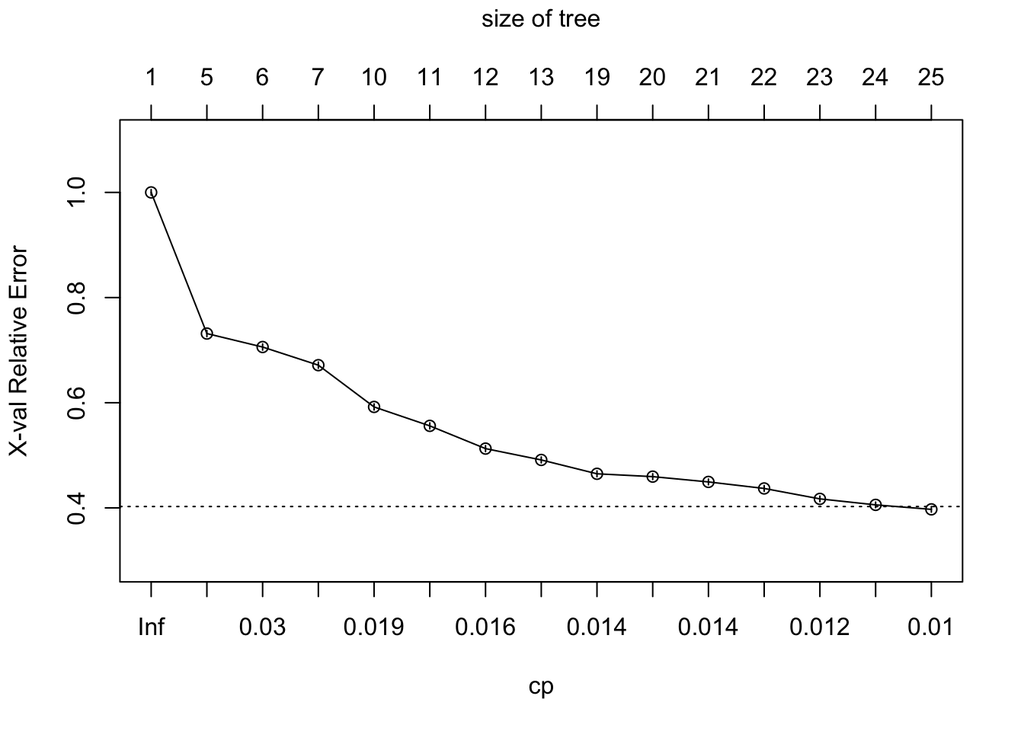

```r
plotcp(rpartFit)
```

The plot and cptable show that the tree should not be pruned. The cross-validation error of 0.3972129 +/- the standard deviation (xstd) of 0.005377592 is between 0.4025905 and 0.3918353. There are no other splits with cross validation values in this range.

#### create a model using boosting

```r
fitControl <- trainControl(method = "repeatedcv",
                           number = 5,
                           repeats = 1)

gbmFit <- train(classe ~ ., data=mtrain, method = "gbm",
                 trControl = fitControl,
                 verbose = FALSE)
```

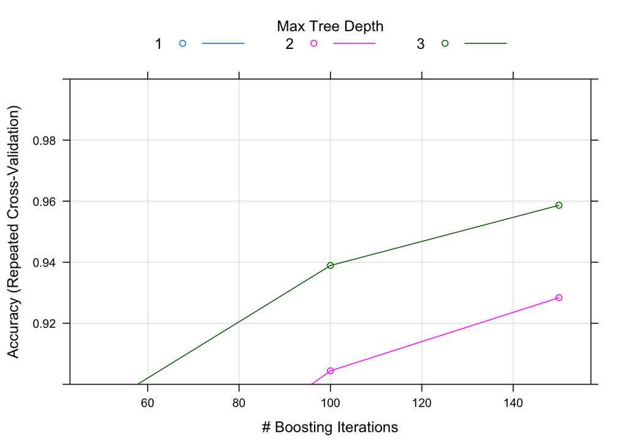

```r
plot(gbmFit, ylim=c(0.9, 1))
```

#### Create a random forest mdoel

```r
rfFit <- randomForest(classe~., data=mtrain, importance=TRUE)
rfFit
```

```
##
## Call:
##  randomForest(formula = classe ~ ., data = mtrain, importance = TRUE)
##                Type of random forest: classification
##                      Number of trees: 500
## No. of variables tried at each split: 6
##
##         OOB estimate of  error rate: 0.62%
## Confusion matrix:
##      A    B    C    D    E class.error
## A 3902    2    1    0    1 0.001024066
## B   12 2641    5    0    0 0.006395786
## C    0   21 2369    5    1 0.011268781
## D    0    0   29 2221    2 0.013765542
## E    0    0    2    4 2519 0.002376238
```

```r
importance(rfFit,type=2)
```

```
##                      MeanDecreaseGini
## pitch_belt                  563.09718
## yaw_belt                    741.37436
## total_accel_belt            242.63422
## gyros_belt_x                 98.12406
## gyros_belt_y                105.47209
## gyros_belt_z                309.05453
## accel_belt_y                125.31968
## magnet_belt_x               213.80370
## magnet_belt_y               381.61180
## magnet_belt_z               375.74672
## roll_arm                    245.25157
## pitch_arm                   132.80429
## yaw_arm                     192.08096
## total_accel_arm              86.01208
## gyros_arm_x                 110.95998
## gyros_arm_y                 110.33442
## gyros_arm_z                  52.95651
## accel_arm_x                 178.83574
## accel_arm_y                 130.66890
## accel_arm_z                 108.56128
## magnet_arm_x                182.63233
## magnet_arm_y                173.62061
## magnet_arm_z                144.80318
## roll_dumbbell               305.36684
## pitch_dumbbell              146.30988
## yaw_dumbbell                200.64493
## total_accel_dumbbell        216.98382
## gyros_dumbbell_x            111.39725
## gyros_dumbbell_y            189.06184
## accel_dumbbell_x            176.07040
## accel_dumbbell_y            312.81967
## accel_dumbbell_z            256.10683
## magnet_dumbbell_x           360.45995
## magnet_dumbbell_y           480.18655
## magnet_dumbbell_z           577.73394
## roll_forearm                417.44077
## pitch_forearm               548.83693
## yaw_forearm                 131.98614
## total_accel_forearm          93.62404
## gyros_forearm_x              67.40566
## gyros_forearm_y             105.17401
## gyros_forearm_z              70.58824
## accel_forearm_x             235.44677
## accel_forearm_y             112.59303
## accel_forearm_z             201.43751
## magnet_forearm_x            164.14750
## magnet_forearm_y            158.86130
## magnet_forearm_z            213.72371
```

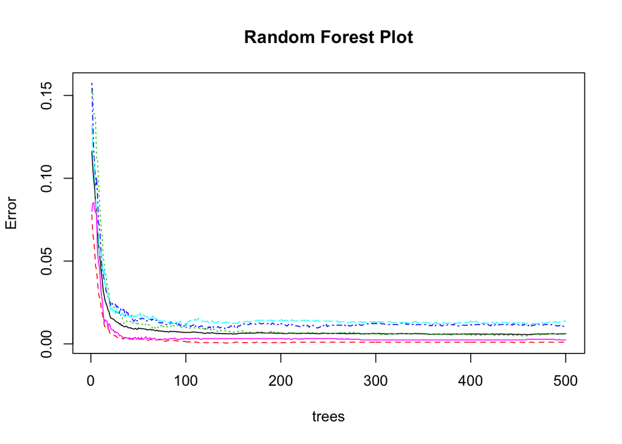

```r
plot(rfFit,main="Random Forest Plot")
```

## Determine Model Accuracy

Find the accuracy of our models by predicting against the test partition created from the training data.

#### prediction accuracy for the classification tree model

```r
pred_r <- predict(rpartFit, newdata=mtest,type="class")
cm_rp <- confusionMatrix(pred_r, mtest$classe)
cm_rp$overall
```

```
##       Accuracy          Kappa  AccuracyLower  AccuracyUpper   AccuracyNull
##   7.254036e-01   6.518633e-01   7.138059e-01   7.367774e-01   2.844520e-01
## AccuracyPValue  McnemarPValue
##   0.000000e+00  5.511735e-101
```

#### prediction accuracy for the random forest.

```r
pred_rf <- predict(rfFit, newdata=mtest)

cm_rf <- confusionMatrix(pred_rf, mtest$classe)
cm_rf$overall
```

```
##       Accuracy          Kappa  AccuracyLower  AccuracyUpper   AccuracyNull
##      0.9957519      0.9946263      0.9937353      0.9972490      0.2844520
## AccuracyPValue  McnemarPValue
##      0.0000000            NaN
```

#### prediction accuracy for boosting.

```r
pred_g <- predict(gbmFit, newdata=mtest)
cm_b <- confusionMatrix(pred_g, mtest$classe)
cm_b$overall
```

```
##       Accuracy          Kappa  AccuracyLower  AccuracyUpper   AccuracyNull
##   0.9605777400   0.9501263207   0.9552874473   0.9654049395   0.2844519966
## AccuracyPValue  McnemarPValue
##   0.0000000000   0.0001401859
```

## Predict values for the test data

#### using random forest

```r
predict(rfFit, newdata=testing)
```

```
##  1  2  3  4  5  6  7  8  9 10 11 12 13 14 15 16 17 18 19 20
##  B  A  B  A  A  E  D  B  A  A  B  C  B  A  E  E  A  B  B  B
## Levels: A B C D E
```

#### using boosting

```r
predict(gbmFit, newdata=testing)
```

```
##  [1] B A B A A E D B A A B C B A E E A B B B
## Levels: A B C D E
```

#### using classification tree

```r
predict(rpartFit, newdata=testing,type="class")
```

```
##  1  2  3  4  5  6  7  8  9 10 11 12 13 14 15 16 17 18 19 20
##  C  A  A  A  A  C  D  D  A  A  C  C  B  A  C  A  A  B  B  B
## Levels: A B C D E
```

## Conclusion

The Random Forest model was the most accurate.

We were able to create accurate prediction models using both random forest and boosting. Our attempt to create a model using a configuration tree was less accurate.

The random forest and boosting models predicted the same results for the test data.

For random forest accuracy was 0.9958 For boosting accuracy was 0.9605 For classification tree accuracy was 0.7254